# My Titanic kaggle implementation in python

Hi ! Here is a little example of Titanic data analysis, in order to guess if someone survived or not.

It will become cleaner with time, for the moment it's just a start :-)

At first, let's describe data ...

```python
import pandas as pd
from sklearn.pipeline import Pipeline
from sklearn.ensemble import RandomForestClassifier
```

```python
working_directory="C:/Users/Jérémie/IdeaProjects/titanic-kaggle-py/"
train_df = pd.read_csv(open(working_directory+"./data/train.csv", 'r'))
```

We have the following columns and data types :

```python
train_df.info()
```

```
<class 'pandas.core.frame.DataFrame'>
RangeIndex: 891 entries, 0 to 890
Data columns (total 12 columns):
PassengerId    891 non-null int64
Survived       891 non-null int64
Pclass         891 non-null int64
Name           891 non-null object
Sex            891 non-null object
Age            714 non-null float64
SibSp          891 non-null int64
Parch          891 non-null int64
Ticket         891 non-null object
Fare           891 non-null float64
Cabin          204 non-null object
Embarked       889 non-null object
dtypes: float64(2), int64(5), object(5)
memory usage: 83.6+ KB
```

`Survived` is an `int64`, but it's in fact a boolean value.

Some objects ? Let's take a look at the data, to see what is in this `object` columns :

```python
train_df.head(100)
```

|  | PassengerId | Survived | Pclass | Name | Sex | Age | SibSp | Parch | Ticket | Fare | Cabin | Embarked |
| --- | --- | --- | --- | --- | --- | --- | --- | --- | --- | --- | --- | --- |
| 0 | 1 | 0 | 3 | Braund, Mr. Owen Harris | male | 22.00 | 1 | 0 | A/5 21171 | 7.2500 | NaN | S |
| 1 | 2 | 1 | 1 | Cumings, Mrs. John Bradley (Florence Briggs Th... | female | 38.00 | 1 | 0 | PC 17599 | 71.2833 | C85 | C |
| 2 | 3 | 1 | 3 | Heikkinen, Miss. Laina | female | 26.00 | 0 | 0 | STON/O2. 3101282 | 7.9250 | NaN | S |
| 3 | 4 | 1 | 1 | Futrelle, Mrs. Jacques Heath (Lily May Peel) | female | 35.00 | 1 | 0 | 113803 | 53.1000 | C123 | S |
| 4 | 5 | 0 | 3 | Allen, Mr. William Henry | male | 35.00 | 0 | 0 | 373450 | 8.0500 | NaN | S |
| 5 | 6 | 0 | 3 | Moran, Mr. James | male | NaN | 0 | 0 | 330877 | 8.4583 | NaN | Q |
| 6 | 7 | 0 | 1 | McCarthy, Mr. Timothy J | male | 54.00 | 0 | 0 | 17463 | 51.8625 | E46 | S |
| 7 | 8 | 0 | 3 | Palsson, Master. Gosta Leonard | male | 2.00 | 3 | 1 | 349909 | 21.0750 | NaN | S |
| 8 | 9 | 1 | 3 | Johnson, Mrs. Oscar W (Elisabeth Vilhelmina Berg) | female | 27.00 | 0 | 2 | 347742 | 11.1333 | NaN | S |
| 9 | 10 | 1 | 2 | Nasser, Mrs. Nicholas (Adele Achem) | female | 14.00 | 1 | 0 | 237736 | 30.0708 | NaN | C |
| 10 | 11 | 1 | 3 | Sandstrom, Miss. Marguerite Rut | female | 4.00 | 1 | 1 | PP 9549 | 16.7000 | G6 | S |
| 11 | 12 | 1 | 1 | Bonnell, Miss. Elizabeth | female | 58.00 | 0 | 0 | 113783 | 26.5500 | C103 | S |
| 12 | 13 | 0 | 3 | Saundercock, Mr. William Henry | male | 20.00 | 0 | 0 | A/5. 2151 | 8.0500 | NaN | S |
| 13 | 14 | 0 | 3 | Andersson, Mr. Anders Johan | male | 39.00 | 1 | 5 | 347082 | 31.2750 | NaN | S |
| 14 | 15 | 0 | 3 | Vestrom, Miss. Hulda Amanda Adolfina | female | 14.00 | 0 | 0 | 350406 | 7.8542 | NaN | S |
| 15 | 16 | 1 | 2 | Hewlett, Mrs. (Mary D Kingcome) | female | 55.00 | 0 | 0 | 248706 | 16.0000 | NaN | S |
| 16 | 17 | 0 | 3 | Rice, Master. Eugene | male | 2.00 | 4 | 1 | 382652 | 29.1250 | NaN | Q |
| 17 | 18 | 1 | 2 | Williams, Mr. Charles Eugene | male | NaN | 0 | 0 | 244373 | 13.0000 | NaN | S |
| 18 | 19 | 0 | 3 | Vander Planke, Mrs. Julius (Emelia Maria Vande... | female | 31.00 | 1 | 0 | 345763 | 18.0000 | NaN | S |
| 19 | 20 | 1 | 3 | Masselmani, Mrs. Fatima | female | NaN | 0 | 0 | 2649 | 7.2250 | NaN | C |
| 20 | 21 | 0 | 2 | Fynney, Mr. Joseph J | male | 35.00 | 0 | 0 | 239865 | 26.0000 | NaN | S |
| 21 | 22 | 1 | 2 | Beesley, Mr. Lawrence | male | 34.00 | 0 | 0 | 248698 | 13.0000 | D56 | S |
| 22 | 23 | 1 | 3 | McGowan, Miss. Anna "Annie" | female | 15.00 | 0 | 0 | 330923 | 8.0292 | NaN | Q |
| 23 | 24 | 1 | 1 | Sloper, Mr. William Thompson | male | 28.00 | 0 | 0 | 113788 | 35.5000 | A6 | S |
| 24 | 25 | 0 | 3 | Palsson, Miss. Torborg Danira | female | 8.00 | 3 | 1 | 349909 | 21.0750 | NaN | S |
| 25 | 26 | 1 | 3 | Asplund, Mrs. Carl Oscar (Selma Augusta Emilia... | female | 38.00 | 1 | 5 | 347077 | 31.3875 | NaN | S |
| 26 | 27 | 0 | 3 | Emir, Mr. Farred Chehab | male | NaN | 0 | 0 | 2631 | 7.2250 | NaN | C |
| 27 | 28 | 0 | 1 | Fortune, Mr. Charles Alexander | male | 19.00 | 3 | 2 | 19950 | 263.0000 | C23 C25 C27 | S |
| 28 | 29 | 1 | 3 | O'Dwyer, Miss. Ellen "Nellie" | female | NaN | 0 | 0 | 330959 | 7.8792 | NaN | Q |
| 29 | 30 | 0 | 3 | Todoroff, Mr. Lalio | male | NaN | 0 | 0 | 349216 | 7.8958 | NaN | S |
| ... | ... | ... | ... | ... | ... | ... | ... | ... | ... | ... | ... | ... |
| 70 | 71 | 0 | 2 | Jenkin, Mr. Stephen Curnow | male | 32.00 | 0 | 0 | C.A. 33111 | 10.5000 | NaN | S |
| 71 | 72 | 0 | 3 | Goodwin, Miss. Lillian Amy | female | 16.00 | 5 | 2 | CA 2144 | 46.9000 | NaN | S |
| 72 | 73 | 0 | 2 | Hood, Mr. Ambrose Jr | male | 21.00 | 0 | 0 | S.O.C. 14879 | 73.5000 | NaN | S |
| 73 | 74 | 0 | 3 | Chronopoulos, Mr. Apostolos | male | 26.00 | 1 | 0 | 2680 | 14.4542 | NaN | C |
| 74 | 75 | 1 | 3 | Bing, Mr. Lee | male | 32.00 | 0 | 0 | 1601 | 56.4958 | NaN | S |
| 75 | 76 | 0 | 3 | Moen, Mr. Sigurd Hansen | male | 25.00 | 0 | 0 | 348123 | 7.6500 | F G73 | S |
| 76 | 77 | 0 | 3 | Staneff, Mr. Ivan | male | NaN | 0 | 0 | 349208 | 7.8958 | NaN | S |
| 77 | 78 | 0 | 3 | Moutal, Mr. Rahamin Haim | male | NaN | 0 | 0 | 374746 | 8.0500 | NaN | S |
| 78 | 79 | 1 | 2 | Caldwell, Master. Alden Gates | male | 0.83 | 0 | 2 | 248738 | 29.0000 | NaN | S |
| 79 | 80 | 1 | 3 | Dowdell, Miss. Elizabeth | female | 30.00 | 0 | 0 | 364516 | 12.4750 | NaN | S |
| 80 | 81 | 0 | 3 | Waelens, Mr. Achille | male | 22.00 | 0 | 0 | 345767 | 9.0000 | NaN | S |
| 81 | 82 | 1 | 3 | Sheerlinck, Mr. Jan Baptist | male | 29.00 | 0 | 0 | 345779 | 9.5000 | NaN | S |
| 82 | 83 | 1 | 3 | McDermott, Miss. Brigdet Delia | female | NaN | 0 | 0 | 330932 | 7.7875 | NaN | Q |
| 83 | 84 | 0 | 1 | Carrau, Mr. Francisco M | male | 28.00 | 0 | 0 | 113059 | 47.1000 | NaN | S |
| 84 | 85 | 1 | 2 | Ilett, Miss. Bertha | female | 17.00 | 0 | 0 | SO/C 14885 | 10.5000 | NaN | S |
| 85 | 86 | 1 | 3 | Backstrom, Mrs. Karl Alfred (Maria Mathilda Gu... | female | 33.00 | 3 | 0 | 3101278 | 15.8500 | NaN | S |
| 86 | 87 | 0 | 3 | Ford, Mr. William Neal | male | 16.00 | 1 | 3 | W./C. 6608 | 34.3750 | NaN | S |
| 87 | 88 | 0 | 3 | Slocovski, Mr. Selman Francis | male | NaN | 0 | 0 | SOTON/OQ 392086 | 8.0500 | NaN | S |
| 88 | 89 | 1 | 1 | Fortune, Miss. Mabel Helen | female | 23.00 | 3 | 2 | 19950 | 263.0000 | C23 C25 C27 | S |
| 89 | 90 | 0 | 3 | Celotti, Mr. Francesco | male | 24.00 | 0 | 0 | 343275 | 8.0500 | NaN | S |
| 90 | 91 | 0 | 3 | Christmann, Mr. Emil | male | 29.00 | 0 | 0 | 343276 | 8.0500 | NaN | S |
| 91 | 92 | 0 | 3 | Andreasson, Mr. Paul Edvin | male | 20.00 | 0 | 0 | 347466 | 7.8542 | NaN | S |
| 92 | 93 | 0 | 1 | Chaffee, Mr. Herbert Fuller | male | 46.00 | 1 | 0 | W.E.P. 5734 | 61.1750 | E31 | S |
| 93 | 94 | 0 | 3 | Dean, Mr. Bertram Frank | male | 26.00 | 1 | 2 | C.A. 2315 | 20.5750 | NaN | S |
| 94 | 95 | 0 | 3 | Coxon, Mr. Daniel | male | 59.00 | 0 | 0 | 364500 | 7.2500 | NaN | S |
| 95 | 96 | 0 | 3 | Shorney, Mr. Charles Joseph | male | NaN | 0 | 0 | 374910 | 8.0500 | NaN | S |
| 96 | 97 | 0 | 1 | Goldschmidt, Mr. George B | male | 71.00 | 0 | 0 | PC 17754 | 34.6542 | A5 | C |
| 97 | 98 | 1 | 1 | Greenfield, Mr. William Bertram | male | 23.00 | 0 | 1 | PC 17759 | 63.3583 | D10 D12 | C |
| 98 | 99 | 1 | 2 | Doling, Mrs. John T (Ada Julia Bone) | female | 34.00 | 0 | 1 | 231919 | 23.0000 | NaN | S |
| 99 | 100 | 0 | 2 | Kantor, Mr. Sinai | male | 34.00 | 1 | 0 | 244367 | 26.0000 | NaN | S |

100 rows × 12 columns

`Name` is a String, a concatenation of last name then first name. It will need some processing.

`Sex` is a qualitative variable.

`Ticket` is quite ugly, as of `Cabin`. Maybe we will work on this at last.

`Embarked` is a qualitative variable.

`Pclass` is an int, but also a qualitative variable.

##### Data Visualization

We now import bokeh's libs:

```python
from bokeh.io import output_notebook, show
from bokeh.charts import Histogram, Donut, Bar
from bokeh.palettes import brewer, Spectral6

pal = brewer["Spectral"][4]
oneColor = pal[0]
output_notebook()
```

And now seaborn's:

```python
%matplotlib inline
import seaborn as sns
sns.set(style="whitegrid", color_codes=True)
```

```python
hist = Histogram(train_df.dropna(),
                 values="Age",
                 title="Age Distribution on Titanic",
                 color=oneColor,
                 bins=20)
show(hist)
```

[interactive chart not shown]

```python
p = Histogram(train_df,
              values="Fare",
              title="Fare Distribution on Titanic",
              color=oneColor)
show(p)
```

[interactive chart not shown]

```python
p = Bar(train_df,
        'Survived',
        color='Survived',
        palette=pal,
        title="Number of survived people and not",
        legend='top_right')
#deprecation warning : https://github.com/bokeh/bokeh/pull/6278
show(p)
```

[interactive chart not shown]

```python
hist = Bar(train_df.dropna()["SibSp"],
           "SibSp",
           color='SibSp',
           palette=pal,
           title="Number of siblings",
           legend='top_right')
show(hist)
```

[interactive chart not shown]

```python
pie_chart = Donut(train_df["Sex"], palette=pal)
show(pie_chart)
```

[interactive chart not shown]

Let's see if male and female as the same ratio at surviving :

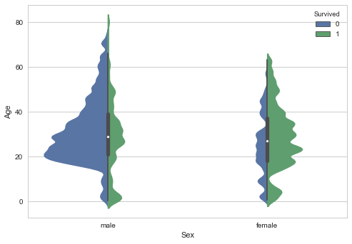

```python
sns.violinplot(x="Sex", y="Age", hue="Survived", data=train_df[["Sex","Survived","Age"]], split=True,
               bw=.1, scale="count", scale_hue=False);
```

We can see that men where more likely to die than women.

Age seem to be correlated, for example very few women of age 8 and men of age 20 survived.

```python
pie_chart = Donut(train_df["Embarked"], palette=pal)
show(pie_chart)
```

[interactive chart not shown]

```python
df = pd.melt(train_df[["Embarked","Sex"]], id_vars=['Sex'],
             value_vars=['male', 'female'],
             value_name='count', var_name='sex')
```

## Initialization of Machine Learning Workflow

Now we are going to train model on the data, without data transformation. We will use only the few numeric ones.

First, we split the dataset :

```python
from sklearn.model_selection import train_test_split

columns = ["Fare", "Pclass","SibSp","Parch"]

labels = train_df["Survived"].values
features = train_df[list(columns)].values

X_train, X_test, y_train, y_test = train_test_split(features, labels, test_size=0.3, random_state=0)
```

Let's use a fonction to save our models :

```python
import os
from time import gmtime, strftime

def save_model(modelPath=working_directory+'./model/', column_names='error',
               score=0, model='error no model', comments='', logLevel="DEBUG"):
    file_name = modelPath+"results.csv"

    if os.path.exists(file_name):
        append_write = 'a' # append if already exists
    else:
        append_write = 'w' # make a new file if not

    result_file = open(file_name,append_write)
    if append_write == 'w':
        result_file.write("Time;Score;Columns;Model;Comments" + '\n')

    result= strftime("%Y-%m-%d %H:%M:%S", gmtime())+ ';' +str(score)+';'+''.join(map(str, column_names))+';'+''.join(str(model).splitlines())+';'+comments
    result_file.write(result + '\n')
    result_file.close()

    #TODO: it could be nice to store model's training time1
```

Go for a quick svm :

```python
from sklearn import svm

clf = svm.SVC(kernel='linear', C=1).fit(X_train, y_train)
print(clf.score(X_test, y_test)   )

save_model(column_names=columns, score=clf.score(X_test, y_test) , model=clf, comments='Trying a naive SVM')
```

```
0.694029850746
```

```python
from sklearn.ensemble import RandomForestClassifier
from sklearn.model_selection import cross_val_score
from sklearn.model_selection import train_test_split

train_df = pd.read_csv(open("C:/Users/Jérémie/IdeaProjects/titanic-kaggle-py/data/train.csv", 'r'))

rf = RandomForestClassifier(n_estimators=1000, max_depth=None, min_samples_split=3, random_state=0)

X_train, X_test, y_train, y_test = train_test_split(features, labels, test_size=0.3, random_state=0)

clf = rf.fit(X_train, y_train)
print(clf.score(X_test, y_test))
model = rf

y_true, y_pred = y_test, clf.predict(X_test)
print(accuracy_score(y_true, y_pred))
```

```
0.716417910448
0.716417910448
```

Score is sligthy better with a random forest ... Let's use it for the begining

```python
## I don't really know what this piece of code really do. Seems to be a croos validation but it's strange to have such a score ...
cross_val_result = cross_val_score(model, X_train, y_train, cv=5, n_jobs=-1)
score_mean = cross_val_result.mean()
score_max = cross_val_result.max()

print("{0} -> RF mean: {1}".format(columns, score_mean))
print("{0} -> RF_max: {1}".format(columns, score_max))
```

```
['Fare', 'Pclass', 'SibSp', 'Parch'] -> RF mean: 0.6773208397337429
['Fare', 'Pclass', 'SibSp', 'Parch'] -> RF_max: 0.696
```

```python
save_model(column_names=columns, score=clf.score(X_test, y_test), model=rf, comments='first random forest model and plumbing. With the good score estimation')
```

Let's try a grid search with a Random Forest model, which will be our reference :

```python
from sklearn.model_selection import GridSearchCV
from sklearn.metrics import classification_report
from sklearn.metrics import accuracy_score

# Set the parameters by cross-validation
tuned_parameters = [{'n_estimators': [10, 100, 1000],
                     'min_samples_split': [2,3]}]
```

```python
clf = GridSearchCV(RandomForestClassifier(), tuned_parameters, cv=5,
                   scoring='accuracy', n_jobs=-1)
clf.fit(X_train, y_train)
```

```
GridSearchCV(cv=5, error_score='raise',
       estimator=RandomForestClassifier(bootstrap=True, class_weight=None, criterion='gini',
            max_depth=None, max_features='auto', max_leaf_nodes=None,
            min_impurity_split=1e-07, min_samples_leaf=1,
            min_samples_split=2, min_weight_fraction_leaf=0.0,
            n_estimators=10, n_jobs=1, oob_score=False, random_state=None,
            verbose=0, warm_start=False),
       fit_params={}, iid=True, n_jobs=-1,
       param_grid=[{'n_estimators': [10, 100, 1000], 'min_samples_split': [2, 3]}],
       pre_dispatch='2*n_jobs', refit=True, return_train_score=True,
       scoring='accuracy', verbose=0)
```

```python
print(clf.score(X_test, y_test))
```

```
0.723880597015
```

```python
clf.best_params_
```

```
{'min_samples_split': 3, 'n_estimators': 100}
```

```python
y_true, y_pred = y_test, clf.predict(X_test)
print(classification_report(y_true, y_pred))
```

```
             precision    recall  f1-score   support

          0       0.77      0.80      0.78       168
          1       0.64      0.60      0.62       100

avg / total       0.72      0.72      0.72       268
```

```python
print(accuracy_score(y_true, y_pred))
```

```
0.723880597015
```

```python
save_model(column_names=columns, score=clf.score(X_test, y_test), model=rf, comments='second random forest model with grid search and good score estimation')
```

### We now add some data in the ML workflow

Numeric columns with NA's fields can't be use just like that. We will create some new columns with some NA replacement.

```python
working_directory="C:/Users/Jérémie/IdeaProjects/titanic-kaggle-py/"
train_df = pd.read_csv(open(working_directory+"./data/train.csv", 'r'))
train_df['AgeMed'] = train_df['Age'].fillna((train_df['Age'].median()))
train_df['isAgeKnown'] = train_df['Age'].where(train_df["Age"].isnull(), 1).fillna(0).astype(int)
```

```python
train_df = pd.concat([train_df, pd.get_dummies(train_df["Sex"])], axis=1)
train_df = pd.concat([train_df, pd.get_dummies(train_df["Embarked"].fillna("embarkedNotKnown"))], axis=1)
train_df.rename(columns={'C': 'Cherbourg','Q': 'Queenstown', 'S': 'Southampton'}, inplace=True)
train_df["FamilySize"]= train_df["SibSp"]+train_df["Parch"]
```

```python
def extract_Title(row):
    return row["Name"].split(', ' )[1].split(".")[0]
```

```python
train_df["Title"] = train_df.apply(extract_Title,axis=1)
train_df = pd.concat([train_df, pd.get_dummies(train_df["Title"])], axis=1)
```

```python
train_df
```

|  | PassengerId | Survived | Pclass | Name | Sex | Age | SibSp | Parch | Ticket | Fare | ... | Master | Miss | Mlle | Mme | Mr | Mrs | Ms | Rev | Sir | the Countess |
| --- | --- | --- | --- | --- | --- | --- | --- | --- | --- | --- | --- | --- | --- | --- | --- | --- | --- | --- | --- | --- | --- |
| 0 | 1 | 0 | 3 | Braund, Mr. Owen Harris | male | 22.0 | 1 | 0 | A/5 21171 | 7.2500 | ... | 0 | 0 | 0 | 0 | 1 | 0 | 0 | 0 | 0 | 0 |
| 1 | 2 | 1 | 1 | Cumings, Mrs. John Bradley (Florence Briggs Th... | female | 38.0 | 1 | 0 | PC 17599 | 71.2833 | ... | 0 | 0 | 0 | 0 | 0 | 1 | 0 | 0 | 0 | 0 |
| 2 | 3 | 1 | 3 | Heikkinen, Miss. Laina | female | 26.0 | 0 | 0 | STON/O2. 3101282 | 7.9250 | ... | 0 | 1 | 0 | 0 | 0 | 0 | 0 | 0 | 0 | 0 |
| 3 | 4 | 1 | 1 | Futrelle, Mrs. Jacques Heath (Lily May Peel) | female | 35.0 | 1 | 0 | 113803 | 53.1000 | ... | 0 | 0 | 0 | 0 | 0 | 1 | 0 | 0 | 0 | 0 |
| 4 | 5 | 0 | 3 | Allen, Mr. William Henry | male | 35.0 | 0 | 0 | 373450 | 8.0500 | ... | 0 | 0 | 0 | 0 | 1 | 0 | 0 | 0 | 0 | 0 |
| 5 | 6 | 0 | 3 | Moran, Mr. James | male | NaN | 0 | 0 | 330877 | 8.4583 | ... | 0 | 0 | 0 | 0 | 1 | 0 | 0 | 0 | 0 | 0 |
| 6 | 7 | 0 | 1 | McCarthy, Mr. Timothy J | male | 54.0 | 0 | 0 | 17463 | 51.8625 | ... | 0 | 0 | 0 | 0 | 1 | 0 | 0 | 0 | 0 | 0 |
| 7 | 8 | 0 | 3 | Palsson, Master. Gosta Leonard | male | 2.0 | 3 | 1 | 349909 | 21.0750 | ... | 1 | 0 | 0 | 0 | 0 | 0 | 0 | 0 | 0 | 0 |
| 8 | 9 | 1 | 3 | Johnson, Mrs. Oscar W (Elisabeth Vilhelmina Berg) | female | 27.0 | 0 | 2 | 347742 | 11.1333 | ... | 0 | 0 | 0 | 0 | 0 | 1 | 0 | 0 | 0 | 0 |
| 9 | 10 | 1 | 2 | Nasser, Mrs. Nicholas (Adele Achem) | female | 14.0 | 1 | 0 | 237736 | 30.0708 | ... | 0 | 0 | 0 | 0 | 0 | 1 | 0 | 0 | 0 | 0 |
| 10 | 11 | 1 | 3 | Sandstrom, Miss. Marguerite Rut | female | 4.0 | 1 | 1 | PP 9549 | 16.7000 | ... | 0 | 1 | 0 | 0 | 0 | 0 | 0 | 0 | 0 | 0 |
| 11 | 12 | 1 | 1 | Bonnell, Miss. Elizabeth | female | 58.0 | 0 | 0 | 113783 | 26.5500 | ... | 0 | 1 | 0 | 0 | 0 | 0 | 0 | 0 | 0 | 0 |
| 12 | 13 | 0 | 3 | Saundercock, Mr. William Henry | male | 20.0 | 0 | 0 | A/5. 2151 | 8.0500 | ... | 0 | 0 | 0 | 0 | 1 | 0 | 0 | 0 | 0 | 0 |
| 13 | 14 | 0 | 3 | Andersson, Mr. Anders Johan | male | 39.0 | 1 | 5 | 347082 | 31.2750 | ... | 0 | 0 | 0 | 0 | 1 | 0 | 0 | 0 | 0 | 0 |
| 14 | 15 | 0 | 3 | Vestrom, Miss. Hulda Amanda Adolfina | female | 14.0 | 0 | 0 | 350406 | 7.8542 | ... | 0 | 1 | 0 | 0 | 0 | 0 | 0 | 0 | 0 | 0 |
| 15 | 16 | 1 | 2 | Hewlett, Mrs. (Mary D Kingcome) | female | 55.0 | 0 | 0 | 248706 | 16.0000 | ... | 0 | 0 | 0 | 0 | 0 | 1 | 0 | 0 | 0 | 0 |
| 16 | 17 | 0 | 3 | Rice, Master. Eugene | male | 2.0 | 4 | 1 | 382652 | 29.1250 | ... | 1 | 0 | 0 | 0 | 0 | 0 | 0 | 0 | 0 | 0 |
| 17 | 18 | 1 | 2 | Williams, Mr. Charles Eugene | male | NaN | 0 | 0 | 244373 | 13.0000 | ... | 0 | 0 | 0 | 0 | 1 | 0 | 0 | 0 | 0 | 0 |
| 18 | 19 | 0 | 3 | Vander Planke, Mrs. Julius (Emelia Maria Vande... | female | 31.0 | 1 | 0 | 345763 | 18.0000 | ... | 0 | 0 | 0 | 0 | 0 | 1 | 0 | 0 | 0 | 0 |
| 19 | 20 | 1 | 3 | Masselmani, Mrs. Fatima | female | NaN | 0 | 0 | 2649 | 7.2250 | ... | 0 | 0 | 0 | 0 | 0 | 1 | 0 | 0 | 0 | 0 |
| 20 | 21 | 0 | 2 | Fynney, Mr. Joseph J | male | 35.0 | 0 | 0 | 239865 | 26.0000 | ... | 0 | 0 | 0 | 0 | 1 | 0 | 0 | 0 | 0 | 0 |
| 21 | 22 | 1 | 2 | Beesley, Mr. Lawrence | male | 34.0 | 0 | 0 | 248698 | 13.0000 | ... | 0 | 0 | 0 | 0 | 1 | 0 | 0 | 0 | 0 | 0 |
| 22 | 23 | 1 | 3 | McGowan, Miss. Anna "Annie" | female | 15.0 | 0 | 0 | 330923 | 8.0292 | ... | 0 | 1 | 0 | 0 | 0 | 0 | 0 | 0 | 0 | 0 |
| 23 | 24 | 1 | 1 | Sloper, Mr. William Thompson | male | 28.0 | 0 | 0 | 113788 | 35.5000 | ... | 0 | 0 | 0 | 0 | 1 | 0 | 0 | 0 | 0 | 0 |
| 24 | 25 | 0 | 3 | Palsson, Miss. Torborg Danira | female | 8.0 | 3 | 1 | 349909 | 21.0750 | ... | 0 | 1 | 0 | 0 | 0 | 0 | 0 | 0 | 0 | 0 |
| 25 | 26 | 1 | 3 | Asplund, Mrs. Carl Oscar (Selma Augusta Emilia... | female | 38.0 | 1 | 5 | 347077 | 31.3875 | ... | 0 | 0 | 0 | 0 | 0 | 1 | 0 | 0 | 0 | 0 |
| 26 | 27 | 0 | 3 | Emir, Mr. Farred Chehab | male | NaN | 0 | 0 | 2631 | 7.2250 | ... | 0 | 0 | 0 | 0 | 1 | 0 | 0 | 0 | 0 | 0 |
| 27 | 28 | 0 | 1 | Fortune, Mr. Charles Alexander | male | 19.0 | 3 | 2 | 19950 | 263.0000 | ... | 0 | 0 | 0 | 0 | 1 | 0 | 0 | 0 | 0 | 0 |
| 28 | 29 | 1 | 3 | O'Dwyer, Miss. Ellen "Nellie" | female | NaN | 0 | 0 | 330959 | 7.8792 | ... | 0 | 1 | 0 | 0 | 0 | 0 | 0 | 0 | 0 | 0 |
| 29 | 30 | 0 | 3 | Todoroff, Mr. Lalio | male | NaN | 0 | 0 | 349216 | 7.8958 | ... | 0 | 0 | 0 | 0 | 1 | 0 | 0 | 0 | 0 | 0 |
| ... | ... | ... | ... | ... | ... | ... | ... | ... | ... | ... | ... | ... | ... | ... | ... | ... | ... | ... | ... | ... | ... |
| 861 | 862 | 0 | 2 | Giles, Mr. Frederick Edward | male | 21.0 | 1 | 0 | 28134 | 11.5000 | ... | 0 | 0 | 0 | 0 | 1 | 0 | 0 | 0 | 0 | 0 |
| 862 | 863 | 1 | 1 | Swift, Mrs. Frederick Joel (Margaret Welles Ba... | female | 48.0 | 0 | 0 | 17466 | 25.9292 | ... | 0 | 0 | 0 | 0 | 0 | 1 | 0 | 0 | 0 | 0 |
| 863 | 864 | 0 | 3 | Sage, Miss. Dorothy Edith "Dolly" | female | NaN | 8 | 2 | CA. 2343 | 69.5500 | ... | 0 | 1 | 0 | 0 | 0 | 0 | 0 | 0 | 0 | 0 |
| 864 | 865 | 0 | 2 | Gill, Mr. John William | male | 24.0 | 0 | 0 | 233866 | 13.0000 | ... | 0 | 0 | 0 | 0 | 1 | 0 | 0 | 0 | 0 | 0 |
| 865 | 866 | 1 | 2 | Bystrom, Mrs. (Karolina) | female | 42.0 | 0 | 0 | 236852 | 13.0000 | ... | 0 | 0 | 0 | 0 | 0 | 1 | 0 | 0 | 0 | 0 |
| 866 | 867 | 1 | 2 | Duran y More, Miss. Asuncion | female | 27.0 | 1 | 0 | SC/PARIS 2149 | 13.8583 | ... | 0 | 1 | 0 | 0 | 0 | 0 | 0 | 0 | 0 | 0 |
| 867 | 868 | 0 | 1 | Roebling, Mr. Washington Augustus II | male | 31.0 | 0 | 0 | PC 17590 | 50.4958 | ... | 0 | 0 | 0 | 0 | 1 | 0 | 0 | 0 | 0 | 0 |
| 868 | 869 | 0 | 3 | van Melkebeke, Mr. Philemon | male | NaN | 0 | 0 | 345777 | 9.5000 | ... | 0 | 0 | 0 | 0 | 1 | 0 | 0 | 0 | 0 | 0 |
| 869 | 870 | 1 | 3 | Johnson, Master. Harold Theodor | male | 4.0 | 1 | 1 | 347742 | 11.1333 | ... | 1 | 0 | 0 | 0 | 0 | 0 | 0 | 0 | 0 | 0 |
| 870 | 871 | 0 | 3 | Balkic, Mr. Cerin | male | 26.0 | 0 | 0 | 349248 | 7.8958 | ... | 0 | 0 | 0 | 0 | 1 | 0 | 0 | 0 | 0 | 0 |
| 871 | 872 | 1 | 1 | Beckwith, Mrs. Richard Leonard (Sallie Monypeny) | female | 47.0 | 1 | 1 | 11751 | 52.5542 | ... | 0 | 0 | 0 | 0 | 0 | 1 | 0 | 0 | 0 | 0 |
| 872 | 873 | 0 | 1 | Carlsson, Mr. Frans Olof | male | 33.0 | 0 | 0 | 695 | 5.0000 | ... | 0 | 0 | 0 | 0 | 1 | 0 | 0 | 0 | 0 | 0 |
| 873 | 874 | 0 | 3 | Vander Cruyssen, Mr. Victor | male | 47.0 | 0 | 0 | 345765 | 9.0000 | ... | 0 | 0 | 0 | 0 | 1 | 0 | 0 | 0 | 0 | 0 |
| 874 | 875 | 1 | 2 | Abelson, Mrs. Samuel (Hannah Wizosky) | female | 28.0 | 1 | 0 | P/PP 3381 | 24.0000 | ... | 0 | 0 | 0 | 0 | 0 | 1 | 0 | 0 | 0 | 0 |
| 875 | 876 | 1 | 3 | Najib, Miss. Adele Kiamie "Jane" | female | 15.0 | 0 | 0 | 2667 | 7.2250 | ... | 0 | 1 | 0 | 0 | 0 | 0 | 0 | 0 | 0 | 0 |
| 876 | 877 | 0 | 3 | Gustafsson, Mr. Alfred Ossian | male | 20.0 | 0 | 0 | 7534 | 9.8458 | ... | 0 | 0 | 0 | 0 | 1 | 0 | 0 | 0 | 0 | 0 |
| 877 | 878 | 0 | 3 | Petroff, Mr. Nedelio | male | 19.0 | 0 | 0 | 349212 | 7.8958 | ... | 0 | 0 | 0 | 0 | 1 | 0 | 0 | 0 | 0 | 0 |
| 878 | 879 | 0 | 3 | Laleff, Mr. Kristo | male | NaN | 0 | 0 | 349217 | 7.8958 | ... | 0 | 0 | 0 | 0 | 1 | 0 | 0 | 0 | 0 | 0 |
| 879 | 880 | 1 | 1 | Potter, Mrs. Thomas Jr (Lily Alexenia Wilson) | female | 56.0 | 0 | 1 | 11767 | 83.1583 | ... | 0 | 0 | 0 | 0 | 0 | 1 | 0 | 0 | 0 | 0 |
| 880 | 881 | 1 | 2 | Shelley, Mrs. William (Imanita Parrish Hall) | female | 25.0 | 0 | 1 | 230433 | 26.0000 | ... | 0 | 0 | 0 | 0 | 0 | 1 | 0 | 0 | 0 | 0 |
| 881 | 882 | 0 | 3 | Markun, Mr. Johann | male | 33.0 | 0 | 0 | 349257 | 7.8958 | ... | 0 | 0 | 0 | 0 | 1 | 0 | 0 | 0 | 0 | 0 |
| 882 | 883 | 0 | 3 | Dahlberg, Miss. Gerda Ulrika | female | 22.0 | 0 | 0 | 7552 | 10.5167 | ... | 0 | 1 | 0 | 0 | 0 | 0 | 0 | 0 | 0 | 0 |
| 883 | 884 | 0 | 2 | Banfield, Mr. Frederick James | male | 28.0 | 0 | 0 | C.A./SOTON 34068 | 10.5000 | ... | 0 | 0 | 0 | 0 | 1 | 0 | 0 | 0 | 0 | 0 |
| 884 | 885 | 0 | 3 | Sutehall, Mr. Henry Jr | male | 25.0 | 0 | 0 | SOTON/OQ 392076 | 7.0500 | ... | 0 | 0 | 0 | 0 | 1 | 0 | 0 | 0 | 0 | 0 |
| 885 | 886 | 0 | 3 | Rice, Mrs. William (Margaret Norton) | female | 39.0 | 0 | 5 | 382652 | 29.1250 | ... | 0 | 0 | 0 | 0 | 0 | 1 | 0 | 0 | 0 | 0 |
| 886 | 887 | 0 | 2 | Montvila, Rev. Juozas | male | 27.0 | 0 | 0 | 211536 | 13.0000 | ... | 0 | 0 | 0 | 0 | 0 | 0 | 0 | 1 | 0 | 0 |
| 887 | 888 | 1 | 1 | Graham, Miss. Margaret Edith | female | 19.0 | 0 | 0 | 112053 | 30.0000 | ... | 0 | 1 | 0 | 0 | 0 | 0 | 0 | 0 | 0 | 0 |
| 888 | 889 | 0 | 3 | Johnston, Miss. Catherine Helen "Carrie" | female | NaN | 1 | 2 | W./C. 6607 | 23.4500 | ... | 0 | 1 | 0 | 0 | 0 | 0 | 0 | 0 | 0 | 0 |
| 889 | 890 | 1 | 1 | Behr, Mr. Karl Howell | male | 26.0 | 0 | 0 | 111369 | 30.0000 | ... | 0 | 0 | 0 | 0 | 1 | 0 | 0 | 0 | 0 | 0 |
| 890 | 891 | 0 | 3 | Dooley, Mr. Patrick | male | 32.0 | 0 | 0 | 370376 | 7.7500 | ... | 0 | 0 | 0 | 0 | 1 | 0 | 0 | 0 | 0 | 0 |

891 rows × 39 columns

```python
columns = ["Fare", "Pclass","SibSp","Parch",
           "female","male",
           "AgeMed","isAgeKnown",
           "Cherbourg","Queenstown","Southampton",
           "FamilySize",
           "Master", "Miss", "Mr", "Mrs", "Ms", "Rev",
          ]

labels = train_df["Survived"].values
features = train_df[list(columns)].values

X_train, X_test, y_train, y_test = train_test_split(features, labels, test_size=0.3, random_state=0)
```

```python
clf = GridSearchCV(RandomForestClassifier(), tuned_parameters, cv=10,
                   scoring='accuracy', n_jobs=-1)
clf.fit(X_train, y_train)
```

```
GridSearchCV(cv=10, error_score='raise',
       estimator=RandomForestClassifier(bootstrap=True, class_weight=None, criterion='gini',
            max_depth=None, max_features='auto', max_leaf_nodes=None,
            min_impurity_split=1e-07, min_samples_leaf=1,
            min_samples_split=2, min_weight_fraction_leaf=0.0,
            n_estimators=10, n_jobs=1, oob_score=False, random_state=None,
            verbose=0, warm_start=False),
       fit_params={}, iid=True, n_jobs=-1,
       param_grid=[{'n_estimators': [10, 100, 1000], 'min_samples_split': [2, 3]}],
       pre_dispatch='2*n_jobs', refit=True, return_train_score=True,
       scoring='accuracy', verbose=0)
```

```python
y_true, y_pred = y_test, clf.predict(X_test)
print(classification_report(y_true, y_pred))
print(accuracy_score(y_true, y_pred))
```

```
             precision    recall  f1-score   support

          0       0.83      0.85      0.84       168
          1       0.73      0.71      0.72       100

avg / total       0.79      0.79      0.79       268

0.794776119403
```

```python
save_model(column_names=columns, score=accuracy_score(y_true, y_pred), model=clf, comments='grid search and new classified data with grid search')
```

### Now we are going to scale and categorize continuous variables

```python
from sklearn import preprocessing
train_df['Age_scaled'] = preprocessing.scale(train_df['AgeMed'])
train_df['FamilySize_scaled'] = preprocessing.scale(train_df['FamilySize'])
train_df['Pclass_scaled'] = preprocessing.scale(train_df['Pclass'])
```

```
C:\Program Files\Anaconda3\lib\site-packages\sklearn\utils\validation.py:429: DataConversionWarning: Data with input dtype int64 was converted to float64 by the scale function.
  warnings.warn(msg, _DataConversionWarning)
```

```python
columns = ["Fare", "Pclass_scaled","SibSp","Parch",
           "female","male",
           "Age_scaled","isAgeKnown",
           "Cherbourg","Queenstown","Southampton",
           "FamilySize_scaled",
           "Master", "Miss", "Mr", "Mrs", "Ms", "Rev",
          ]

labels = train_df["Survived"].values
features = train_df[list(columns)].values

X_train, X_test, y_train, y_test = train_test_split(features, labels, test_size=0.3, random_state=0)
```

```python
clf = GridSearchCV(RandomForestClassifier(), tuned_parameters, cv=10,
                   scoring='accuracy', n_jobs=-1)
clf.fit(X_train, y_train)
```

```
GridSearchCV(cv=10, error_score='raise',
       estimator=RandomForestClassifier(bootstrap=True, class_weight=None, criterion='gini',
            max_depth=None, max_features='auto', max_leaf_nodes=None,
            min_impurity_split=1e-07, min_samples_leaf=1,
            min_samples_split=2, min_weight_fraction_leaf=0.0,
            n_estimators=10, n_jobs=1, oob_score=False, random_state=None,
            verbose=0, warm_start=False),
       fit_params={}, iid=True, n_jobs=-1,
       param_grid=[{'n_estimators': [10, 100, 1000], 'min_samples_split': [2, 3]}],
       pre_dispatch='2*n_jobs', refit=True, return_train_score=True,
       scoring='accuracy', verbose=0)
```

```python
y_true, y_pred = y_test, clf.predict(X_test)
print(classification_report(y_true, y_pred))
print(accuracy_score(y_true, y_pred))
```

```
             precision    recall  f1-score   support

          0       0.84      0.88      0.86       168
          1       0.78      0.72      0.75       100

avg / total       0.82      0.82      0.82       268

0.820895522388
```

It seems a bit better ...

#### Let's now try a lot of different parameters

```python
#Trying with a new grid test
import numpy as np
# The most common value for the max number of features to look at in each split is sqrt(# of features)
#sqrtfeat = np.sqrt(train_df.shape[1])
sqrtfeat = np.sqrt(train_df.shape[1])

# Simple grid test
grid_test1 = { "n_estimators"      : [1000, 5000],
               "max_features"      : [6, 10, 15],
               "max_depth"         : [5, 10, 25],
               "min_samples_split" : [2, 5, 10] }
```

```python
clf = GridSearchCV(RandomForestClassifier(), grid_test1, cv=10,
                   scoring='accuracy', n_jobs=-1)
clf.fit(X_train, y_train)
```

```
GridSearchCV(cv=10, error_score='raise',
       estimator=RandomForestClassifier(bootstrap=True, class_weight=None, criterion='gini',
            max_depth=None, max_features='auto', max_leaf_nodes=None,
            min_impurity_split=1e-07, min_samples_leaf=1,
            min_samples_split=2, min_weight_fraction_leaf=0.0,
            n_estimators=10, n_jobs=1, oob_score=False, random_state=None,
            verbose=0, warm_start=False),
       fit_params={}, iid=True, n_jobs=-1,
       param_grid={'n_estimators': [1000, 5000], 'max_features': [6, 10, 15], 'max_depth': [5, 10, 25], 'min_samples_split': [2, 5, 10]},
       pre_dispatch='2*n_jobs', refit=True, return_train_score=True,
       scoring='accuracy', verbose=0)
```

```python
y_true, y_pred = y_test, clf.predict(X_test)
print(accuracy_score(y_true, y_pred))
```

```
0.828358208955
```

```python
save_model(column_names=columns,
           score=accuracy_score(y_true, y_pred),
           model=clf, comments='a lot of of hyper parameters, but not a very good score ...')
```

Let's see feature importance :

```python
d = []
for f in range(X_train.shape[1]):
    d.append({'Feature_name': columns[indices[f]], 'importance': importances[indices[f]] })

importance = pd.DataFrame(d)

from bokeh.charts import Bar
from bokeh.charts.attributes import ColorAttr, CatAttr
from bokeh.charts.builders.bar_builder import BarBuilder

p = Bar(importance, values='importance', label=CatAttr(columns=['Feature_name'], sort=False), legend="top_right",
                 color=oneColor)
show(p)
```

[interactive chart not shown]

#### Generate submission file

```python
submit_df = pd.read_csv(open(working_directory+"./data/test.csv", 'r'))
```

```python
def extract_Title(row):
    return row["Name"].split(', ' )[1].split(".")[0]
```

```python
submit_df = pd.read_csv(open(working_directory+"./data/test.csv", 'r'))
submit_df['AgeMean'] = submit_df['Age'].fillna((submit_df['Age'].mean()))
submit_df['AgeMed'] = submit_df['Age'].fillna((submit_df['Age'].median()))
submit_df['isAgeKnown'] = submit_df['Age'].where(submit_df["Age"].isnull(), 1).fillna(0).astype(int)
submit_df = pd.concat([submit_df, pd.get_dummies(submit_df["Sex"])], axis=1)
submit_df = pd.concat([submit_df, pd.get_dummies(submit_df["Embarked"].fillna("embarkedNotKnown"))], axis=1)
submit_df.rename(columns={'C': 'Cherbourg','Q': 'Queenstown', 'S': 'Southampton'}, inplace=True)
submit_df["FamilySize"]= submit_df["SibSp"]+submit_df["Parch"]
submit_df["Title"] = submit_df.apply(extract_Title,axis=1)
submit_df = pd.concat([submit_df, pd.get_dummies(submit_df["Title"])], axis=1)
submit_df['Fare'].fillna((submit_df['Fare'].mean()), inplace=True)

from sklearn import preprocessing
submit_df['Age_scaled'] = preprocessing.scale(submit_df['AgeMed'])
submit_df['FamilySize_scaled'] = preprocessing.scale(submit_df['FamilySize'])
submit_df['Pclass_scaled'] = preprocessing.scale(submit_df['Pclass'])
```

```
C:\Program Files\Anaconda3\lib\site-packages\sklearn\utils\validation.py:429: DataConversionWarning: Data with input dtype int64 was converted to float64 by the scale function.
  warnings.warn(msg, _DataConversionWarning)
```

```python
columns = ["Fare", "Pclass_scaled","SibSp","Parch",
           "female","male",
           "Age_scaled","isAgeKnown",
           "Cherbourg","Queenstown","Southampton",
           "FamilySize_scaled",
           "Master", "Miss", "Mr", "Mrs", "Ms", "Rev"
          ]

features = submit_df[list(columns)].values
```

```python
y_pred = clf.predict(features)
```

```python
submission = pd.DataFrame({
        "PassengerId": submit_df["PassengerId"],
        "Survived": y_pred
    })
```

```python
submission.info()
```

```
<class 'pandas.core.frame.DataFrame'>
RangeIndex: 418 entries, 0 to 417
Data columns (total 2 columns):
PassengerId    418 non-null int64
Survived       418 non-null int64
dtypes: int64(2)
memory usage: 6.6 KB
```

```python
submission.to_csv(working_directory+"./output/submission.csv", index=False)
```

After submitting to kaggle, the score is 0.775 Not very good, and very lower than 0.82 :-( I'll try to have best results on a next one.